# ch3-hw2

2025-03-18

```r
library(astsa)
```

## 3.4

$$\begin{aligned}
x_{t} &= \beta_{0} + \beta_{1}.t + w_{t} \\
E(x_{t}) &= \beta_{0} + \beta_{1}.t
\end{aligned}$$

The mean is not constant, so this is not stationary.

$$\begin{aligned}
\nabla x_{t} = x_{t} - x_{t-1} &= \beta_{0} + \beta_{1}.t + w_{t} -
\beta_{0} - \beta_{1}.(t-1) - w_{t-1} \\
&= \beta_{1} + w_{t} - w_{t-1} \\
E(\nabla x_{t}) &= \beta_{1} \\
\gamma_{\nabla x_{t}}(h) &= Cov(\nabla x_{t}, \nabla x_{t+h}) \\
h=0,\gamma(0) &= Var(\nabla x_{t}) = 0 \\
h=1, \gamma(1) &= Cov(\beta_{1}+w_{t}-w_{t-1}, \beta_{1} + w_{t+1} -
w_{t}) \\
&= -\sigma_{w}^2 \\
h =2, \gamma(2) &= Cov(\beta_{1}+w_{t}-w_{t-1}, \beta_{1} + w_{t+2}
- w_{t+1}) \\
&= 0
\end{aligned}$$

Since, the mean is constant, and the autocovariance is only dependent on h, it is stationary.

$$\begin{aligned}
x_t &= \beta_0 + \beta_1 t + y_t \\
\nabla x_t &= x_t - x_{t-1} \\
\nabla x_t &= (\beta_0 + \beta_1 t + y_t) - (\beta_0 + \beta_1 (t-1)
+ y_{t-1})\\
\nabla x_t &= \beta_1 + y_t - y_{t-1}\\
E[\nabla x_t] &= E[\beta_1 + y_t - y_{t-1}]\\
E[\nabla x_t] &= \beta_1 + \mu_y - \mu_y = \beta_1\\
\gamma_{\nabla x}(h) &= \text{Cov}(\nabla x_t, \nabla x_{t+h})\\
\gamma_{\nabla x}(h) &= \text{Cov}(\beta_1 + y_t - y_{t-1}, \beta_1
+ y_{t+h} - y_{t+h-1})\\
\gamma_{\nabla x}(h) &= \text{Cov}(y_t - y_{t-1}, y_{t+h} -
y_{t+h-1})\\
\gamma_{\nabla x}(h) &= \gamma_y(0) + \gamma_y(0) - \gamma_y(h-1) -
\gamma_y(h+1)\\
\end{aligned}$$

## 3.5

$$\begin{aligned}
E[x_t - x_{t-1}] &= E[\delta + w_t + y_t - y_{t-1}] \\
E[x_t - x_{t-1}] &= \delta + E[w_t] + E[y_t - y_{t-1}] \\
E[x_t - x_{t-1}] &= \delta \\
Var(x_t - x_{t-1}) &= Var(\delta + w_t + y_t - y_{t-1}) \\
Var(x_t - x_{t-1}) &= Var(w_t + y_t - y_{t-1}) \\
\gamma(h) &= Cov(x_t - x_{t-1}, x_{t-h} - x_{t-h-1}) \\
\gamma(h) &= Cov(\delta + w_t + y_t - y_{t-1}, \delta + w_{t-h} +
y_{t-h} - y_{t-h-1}) \\
\gamma(h) &= Cov(w_t + y_t - y_{t-1}, w_{t-h} + y_{t-h} - y_{t-h-1})
\end{aligned}$$

The mean is constant, Variance is constant, and autocovariance is only dependent on h, so it is stationary.

## 3.6

### a

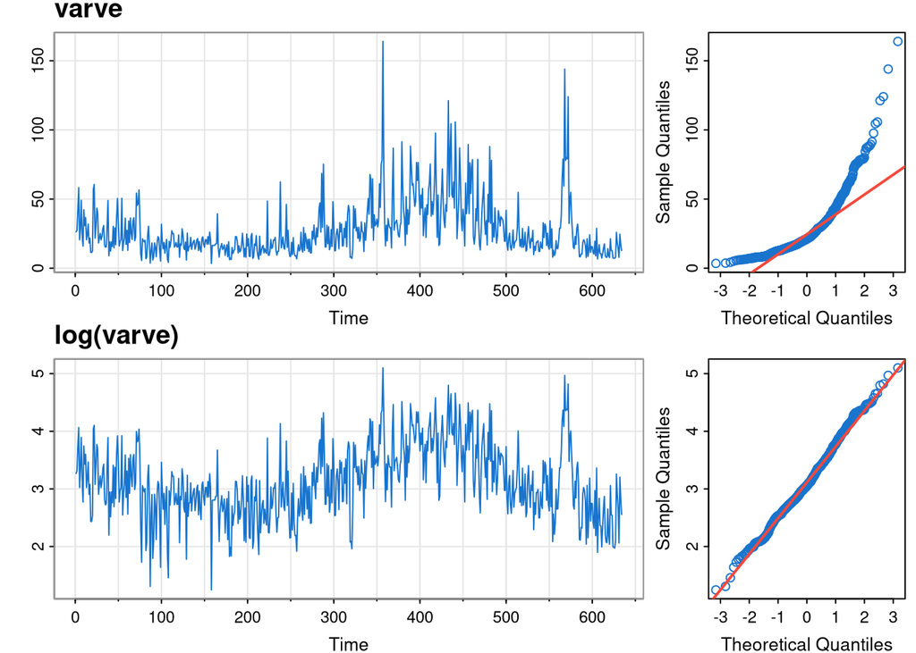

```r
layout(matrix(1:4,2), widths=c(2.5,1))
par(mgp=c(1.6,.6,0), mar=c(2,2,.5,0)+.5)
tsplot(varve, main="", ylab="", col=4, margin=0)
mtext("varve", side=3, line=.5, cex=1.2, font=2, adj=0)
tsplot(log(varve), main="", ylab="", col=4, margin=0)
mtext("log(varve)", side=3, line=.5, cex=1.2, font=2, adj=0)
qqnorm(varve, main="", col=4); qqline(varve, col=2, lwd=2)
qqnorm(log(varve), main="", col=4); qqline(log(varve), col=2, lwd=2)
```

```r
n = length(varve)

first_half = varve[1:(n/2)]
second_half = varve[(n/2 + 1):n]

var(first_half)
```

```
## [1] 133.4574
```

```r
var(second_half)
```

```
## [1] 594.4904
```

As we can see, the variance is very different in the first half compared to the seconds half. So, $x_{t}$ is heteroskedastic.

```r
transformed_varve = log(varve)
first_half = transformed_varve[1:(n/2)]
second_half = transformed_varve[(n/2 + 1):n]

var(first_half)
```

```
## [1] 0.2707217
```

```r
var(second_half)
```

```
## [1] 0.451371
```

These values are much closer.

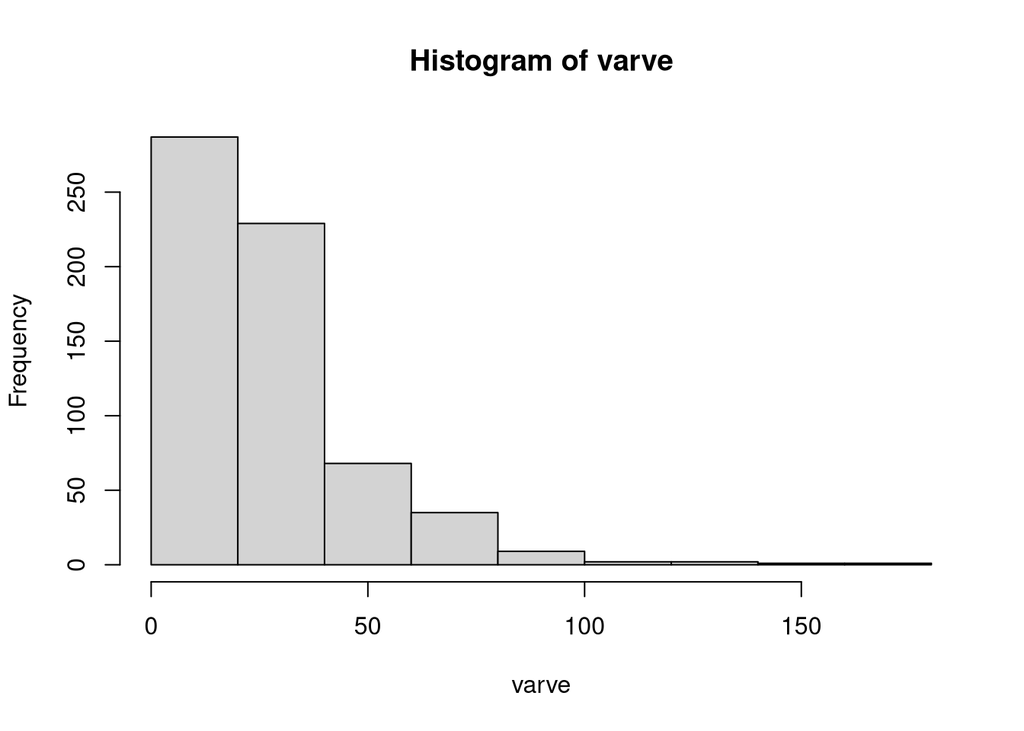

```r
hist(varve)
```

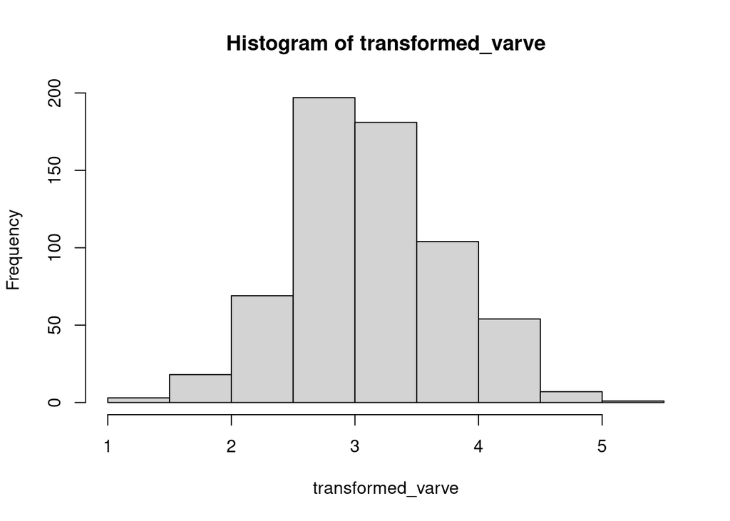

```r
hist(transformed_varve)
```

The new histogram is much closer to a normal distribution compared to $x_{t}$

### b

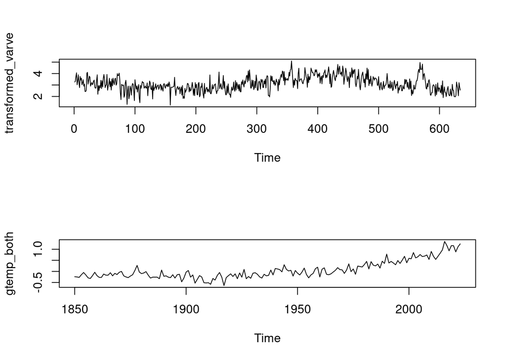

```r
par(mfrow=c(2,1))
plot(transformed_varve)
plot(gtemp_both)
```

### c

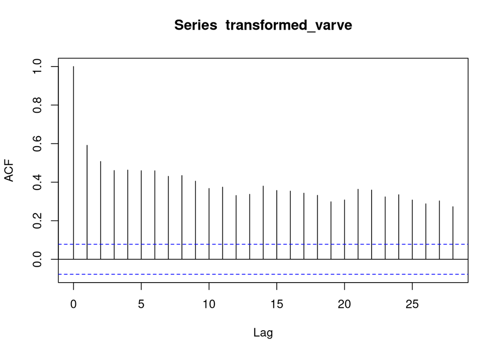

```r
acf(transformed_varve)
```

Based on the sample ACF, there seems to be significant correlation with previous values.

### d

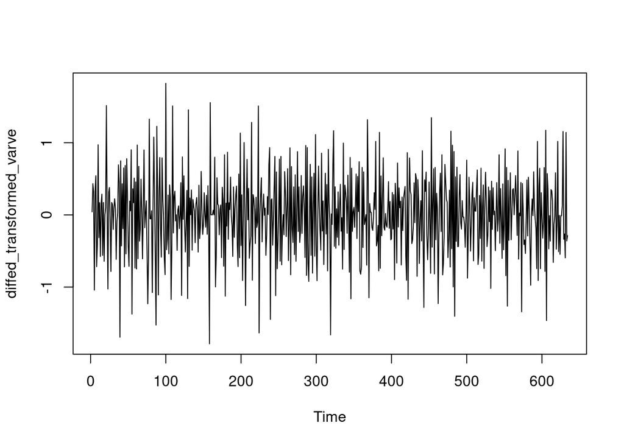

```r
diffed_transformed_varve = diff(transformed_varve)
plot(diffed_transformed_varve)
```

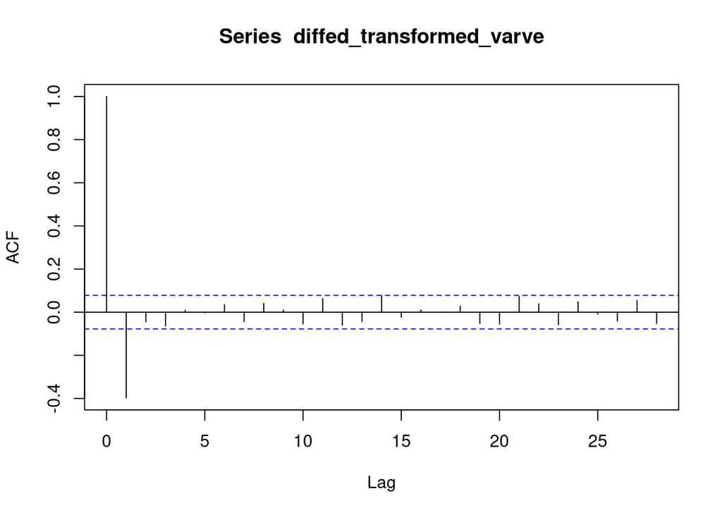

```r
acf(diffed_transformed_varve)
```

```r
first_half = diffed_transformed_varve[1:(n/2)]
second_half = diffed_transformed_varve[(n/2 + 1):n]

mean(first_half, na.rm=TRUE)
```

```
## [1] 0.001489556
```

```r
mean(second_half, na.rm=TRUE)
```

```
## [1] -0.003748562
```

```r
var(first_half, na.rm=TRUE)
```

```
## [1] 0.36509
```

```r
var(second_half, na.rm=TRUE)
```

```
## [1] 0.3002727
```

Based on the new data, the diffed version is stationary. One practical application could be to model the population of a country.

## 3.7

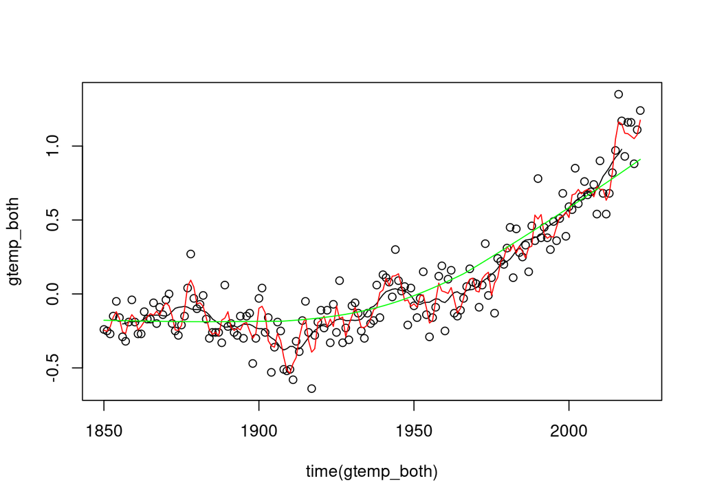

```r
# gtemp_land, gtemp_ocean
plot(time(gtemp_both), gtemp_both)
weights = c(.5, rep(1,11), .5)/12
moving_averaged_data = filter(gtemp_both, sides = 2, filter=weights)
lines(moving_averaged_data)
kernel_smoothed = ksmooth(time(gtemp_both), gtemp_both, bandwidth = 3)
lines(kernel_smoothed, col="red")
lowess_smoothed = lowess(time(gtemp_both), gtemp_both)
lines(lowess_smoothed, col="green")
```

## 3.8

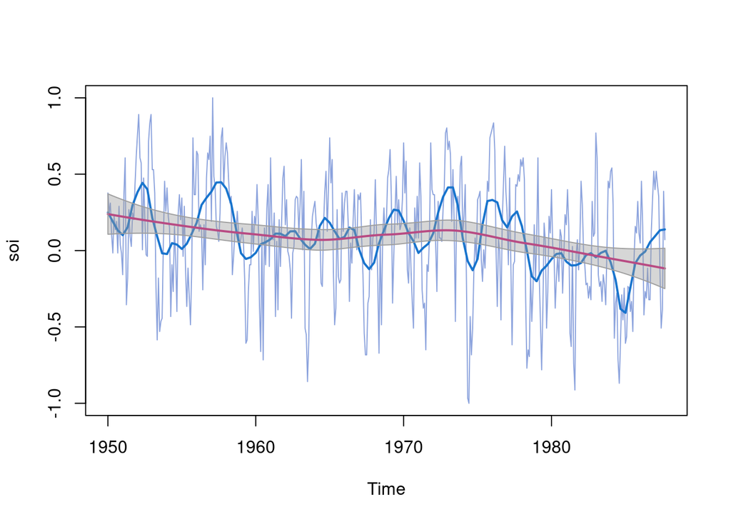

```r
plot(soi, col=rgb(0.5, 0.6, 0.85, .9))
lines(lowess(soi, f=.05), lwd=2, col=4)
lo = predict(loess(soi~ time(soi)), se=TRUE)
trnd = ts(lo$fit, start=1950, freq=12)
lines(trnd, col=6, lwd=2)
L = trnd - qt(0.975, lo$df)*lo$se
U = trnd + qt(0.975, lo$df)*lo$se
xx = c(time(soi), rev(time(soi)))
yy = c(L, rev(U))
polygon(xx, yy, border=8, col=gray(.6, alpha=.4) )

# sinusoidal
trnd = time(soi)
C4 = cos(2*pi*trnd/4)
S4 = sin(2*pi*trnd/4)

sinusoidal_model = lm(soi ~ trnd + C4 + S4)
predicted = fitted(sinusoidal_model)

# lines(soi)
lines(predicted, col="red")
```

## 3.9

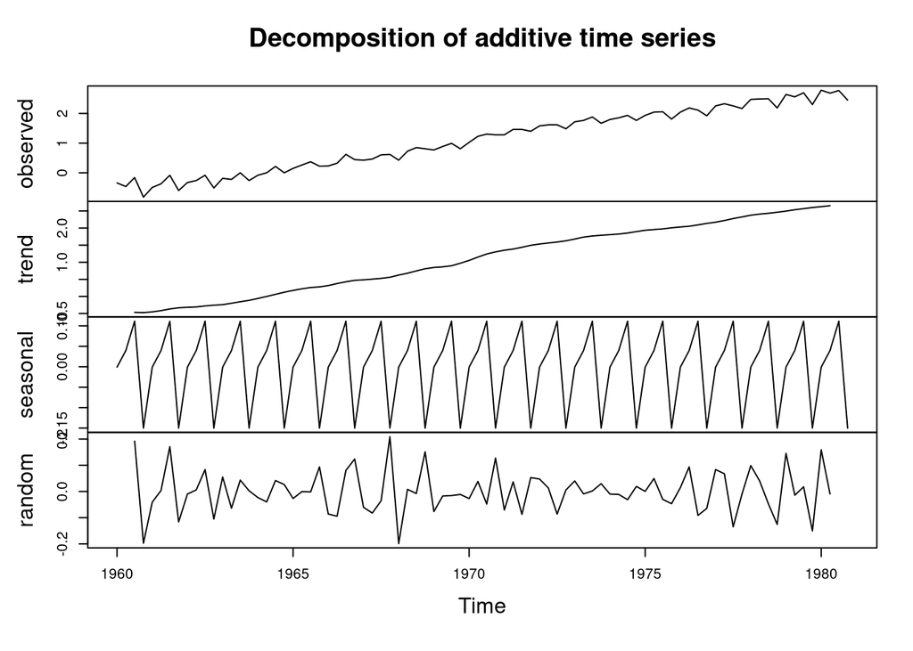

```r
# xt = T + S + N
nx = log(jj)
plot(decompose(nx))
```

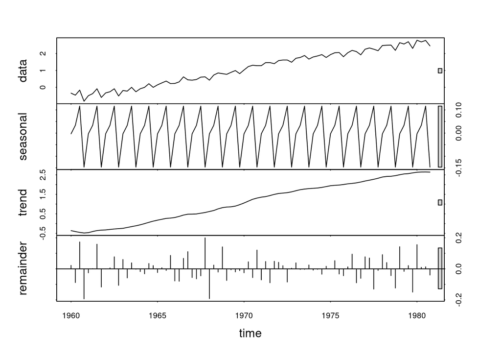

```r
plot(stl(nx, s.window = "periodic"))
```

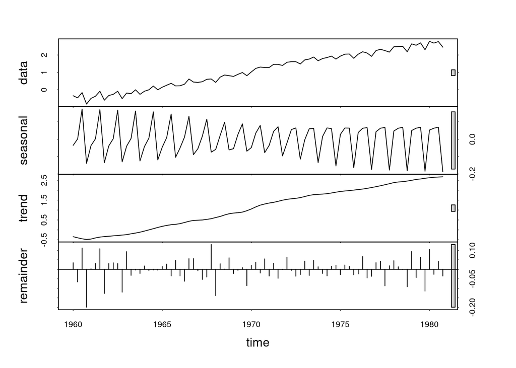

```r
plot(stl(nx, s.window = 15))
```

Based on the plot, all three methods result in similar trend. The seasonal trend is different. THe seasonal trend between stl using periodic and decompose is similar but for last plot the seasonal trend is not constant.